# Assignment 1 - Data Manipulation and Visualization

TU Dortmund SoSe20 - Exploratory Data Analysis

10 June 2020

## Academic Honesty

** This is an individual “open book take-home assignment”. Please do not share your answers with anyone other than yourself. Please do not simply copy answers from classmates or anyone else. It’s fine to use external sources, to discuss, or to ask for help. **

## Packages

In this assignment you will use, at a minimum, the tidyverse package. Load these packages on top of your document.

```r
library(tidyverse)
library(nycflights13)
```

## Introduction

We will use an existing dataset that contains speaking proficiency test scores on an official language exam. These speaking proficiency scores are taken from the State Exam Dutch as a Second Language as administred by the [Dutch Board of Examinations](https://www.hetcvte.nl/item/staatsexamens_nederlands_als). The data are available from https://zenodo.org/record/2863533. This dataset was published alongside a recent study on the effects of language similarity on speaking proficiency (Schepens, Hout, & Jaeger, 2020). The study used three different measures of linguistic similarity:

- a lexical distance measure based on (Gray & Atkinson, 2003) using data that was retrieved from the [the Indo-European Lexical Cognacy Database (IELEX)](http://ielex.mpi.nl/),
- a morphological similarity measure based on [The World Atlas of Language Structures (WALS)](http://wals.info/) (Dryer & Haspelmath, 2011), and
- a phonological distance measure based on data from [Phonetics Information Base and Lexicon (PHOIBLE)](http://phoible.org/) (“PHOIBLE Online,” 2014).

## Questions

1 points

1. Read in the data.

```r
df <- read.csv("https://zenodo.org/record/2863533/files/stex.csv?download=1")
```

3 point

2. How many rows and columns does the dataset have? How many different first languages do the learners speak? Which language is spoken most often?

```r
view(df)
#50235 rows ; 16 columns
length(unique(df[["L1"]]))
```

```
## [1] 70
```

```r
# 70 different first languages
tt <- table(df["L1"])
names(tt[tt==max(tt)])
```

```
## [1] "Arabic"
```

```r
#Arabic spoken most often
```

1 point

3. Make sure that the data does not contain any missing values. Remove the rows with missing values from the dataset.

```r
# 3003 missing values
df <- na.omit(df)
```

3 points

4. Make a histogram of the variable `AaA` (ago at arrival; age at which someone starts to live in the Netherlands). Choose and argue what a good value for `binwidth` is.

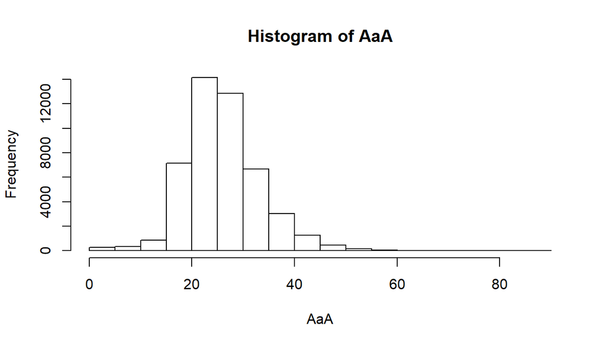

```r
AaA <- df$AaA
hist(AaA)
```

3 points

5. Make a density plot of `AaA` for the most common L1s (L1s with more than 2000 learners). Which L1 hast the highest mode?

```r
tt <- table(df["L1"])
names(tt[tt > 2000])
```

```
## [1] "Arabic"  "English" "German"  "Persian" "Polish"  "Russian" "Serbian"
## [8] "Spanish" "Turkish"
```

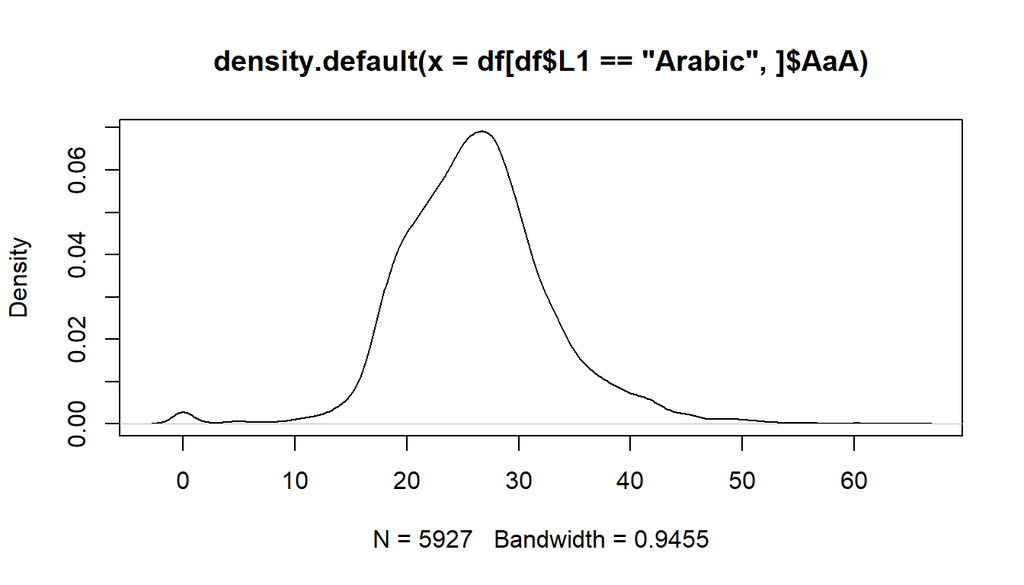

```r
#"Arabic"  "English" "German"  "Persian" "Polish"  "Russian"
#"Serbian" "Spanish" "Turkish"
d <- density(df[df$L1 == "Arabic",]$AaA)
plot(d)
```

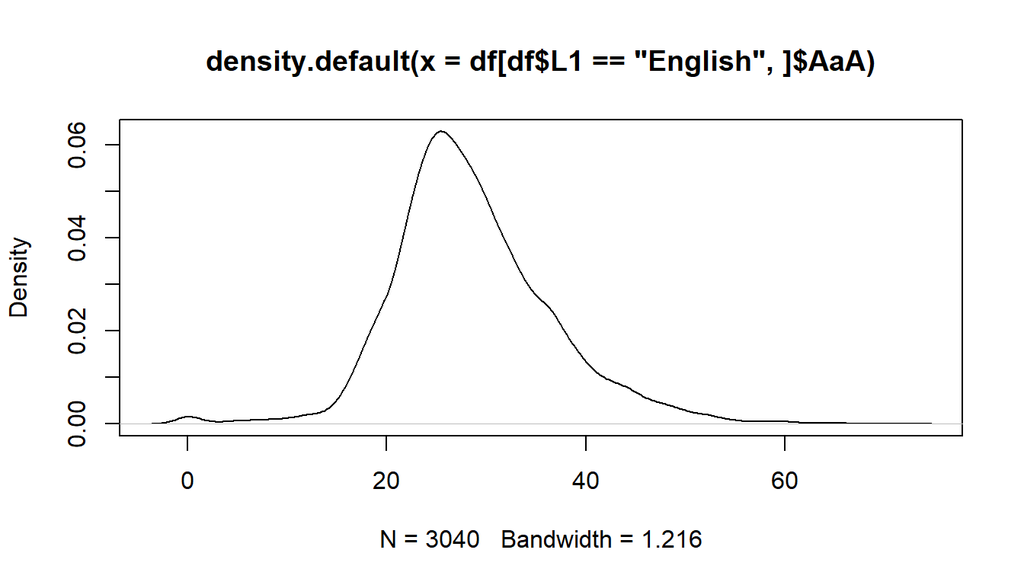

```r
d <- density(df[df$L1 == "English",]$AaA)
plot(d)
```

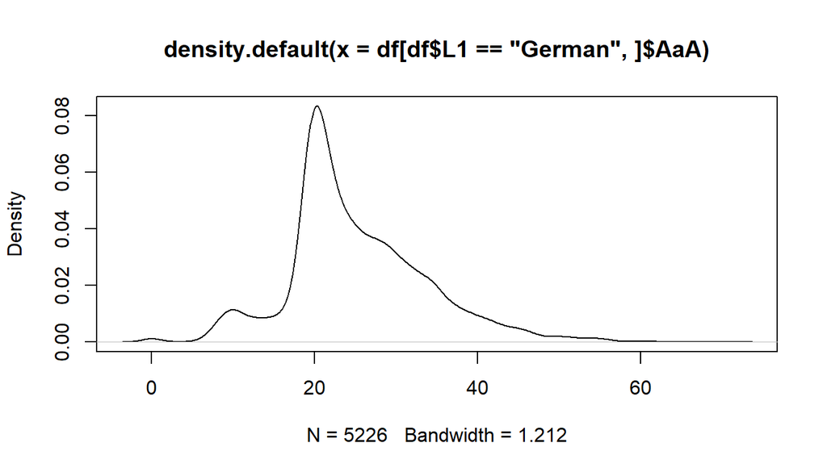

```r
d <- density(df[df$L1 == "German",]$AaA)
plot(d)
```

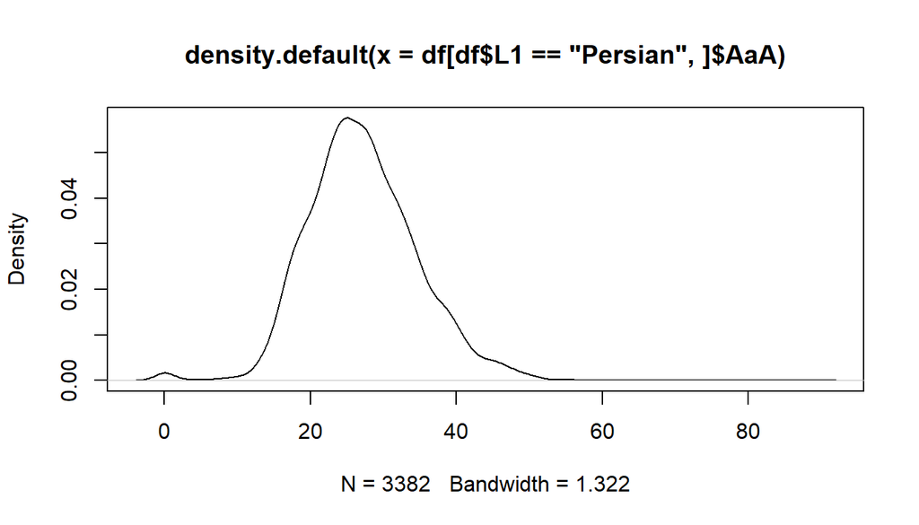

```r
d <- density(df[df$L1 == "Persian",]$AaA)
plot(d)
```

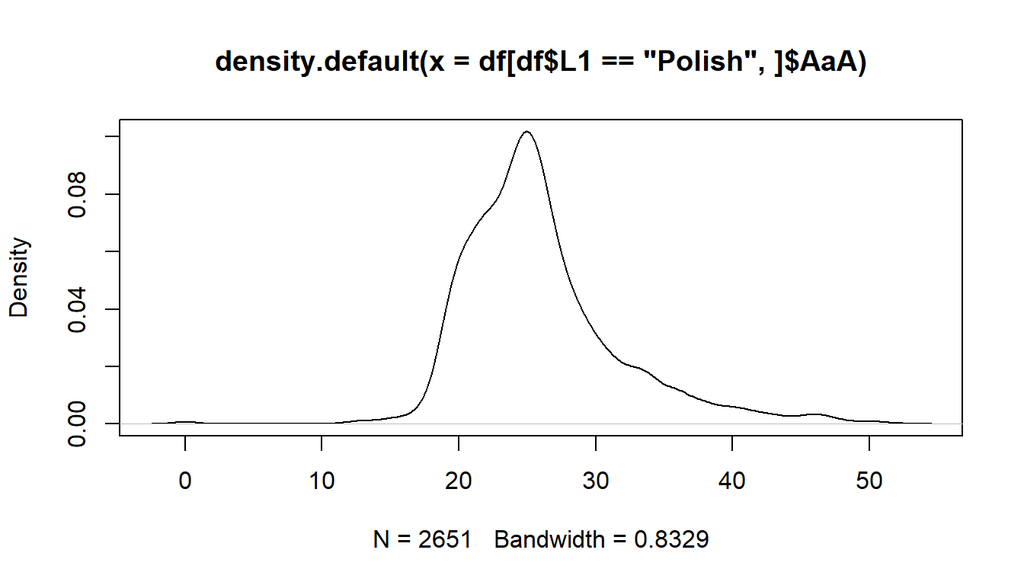

```r
d <- density(df[df$L1 == "Polish",]$AaA)
plot(d)
```

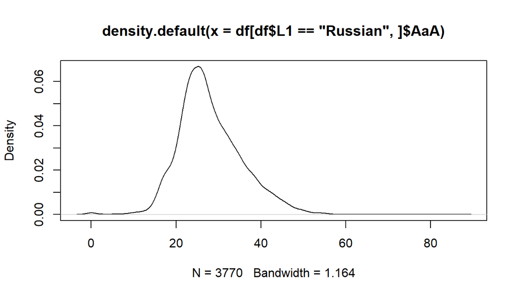

```r
d <- density(df[df$L1 == "Russian",]$AaA)
plot(d)
```

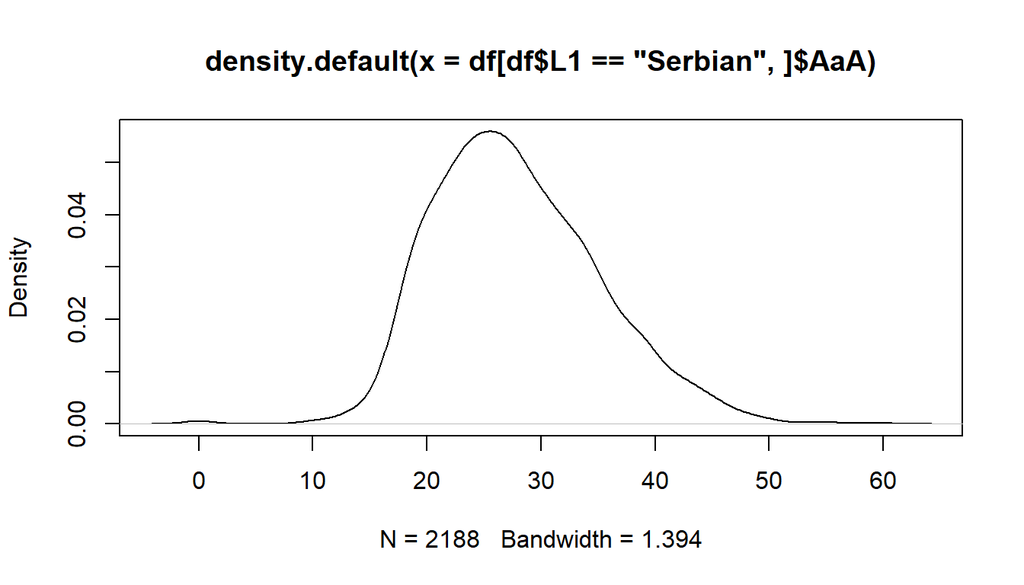

```r
d <- density(df[df$L1 == "Serbian",]$AaA)
plot(d)
```

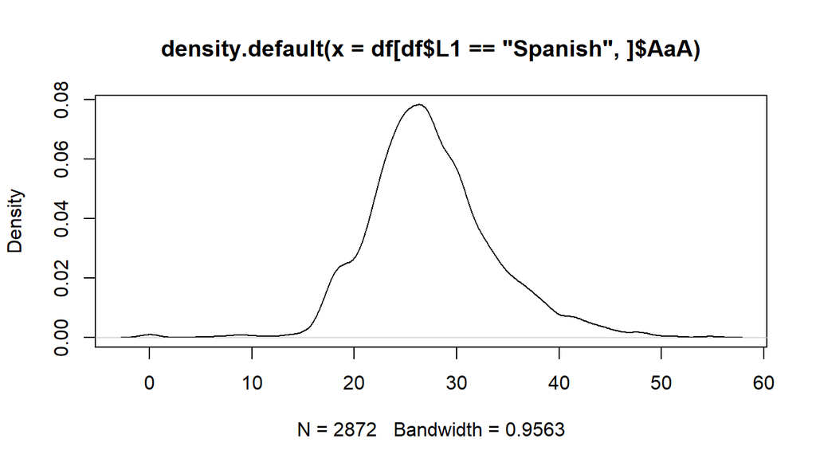

```r
d <- density(df[df$L1 == "Spanish",]$AaA)
plot(d)
```

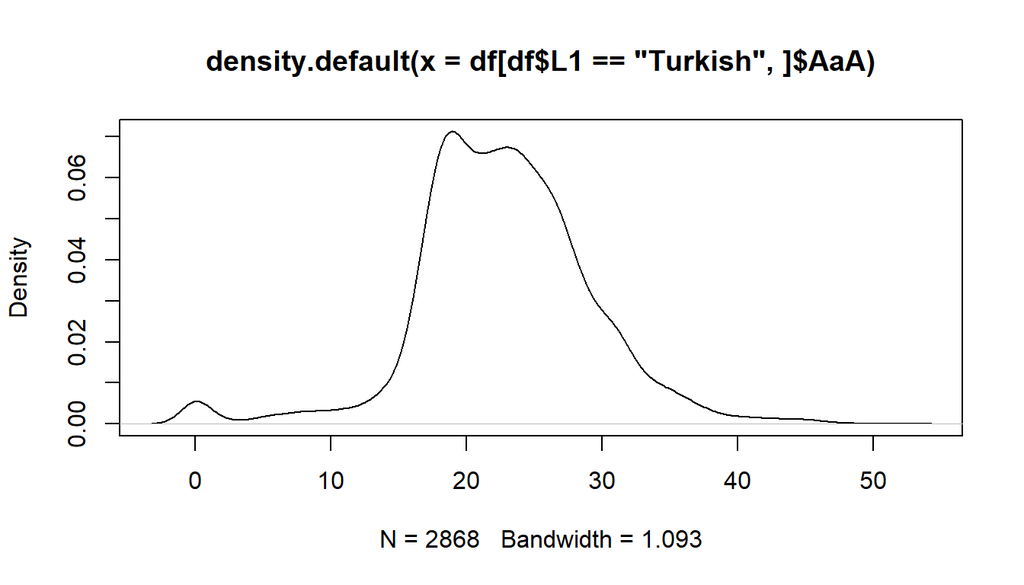

```r
d <- density(df[df$L1 == "Turkish",]$AaA)
plot(d)
```

5 points

6. Make a faceted scatterplot for the most common L1s (using the subset from question 5) with speaking proficiency and age of arrival. Add a blue smooth line (geom_smooth) and a red straight line geom_smooth(method = “lm”) to your scatterplots using `color = "blue"` or `color = "red"`. Describe the relationship between age of arrival and speaking proficiency.

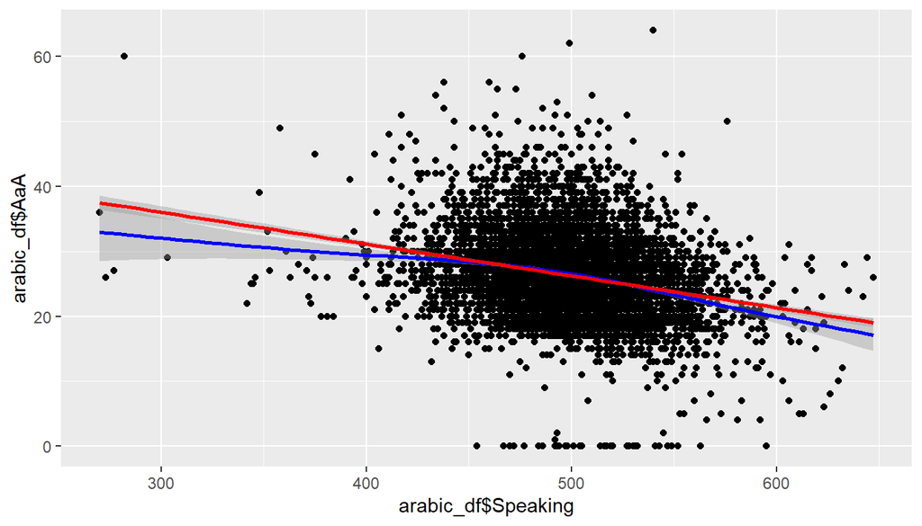

```r
arabic_df <- df[df$L1 == "Arabic",]
ggplot(arabic_df, aes(x = arabic_df$Speaking, y = arabic_df$AaA)) + geom_point() + geom_smooth(color = "blue") + geom_smooth(method = "lm", color = "red")
```

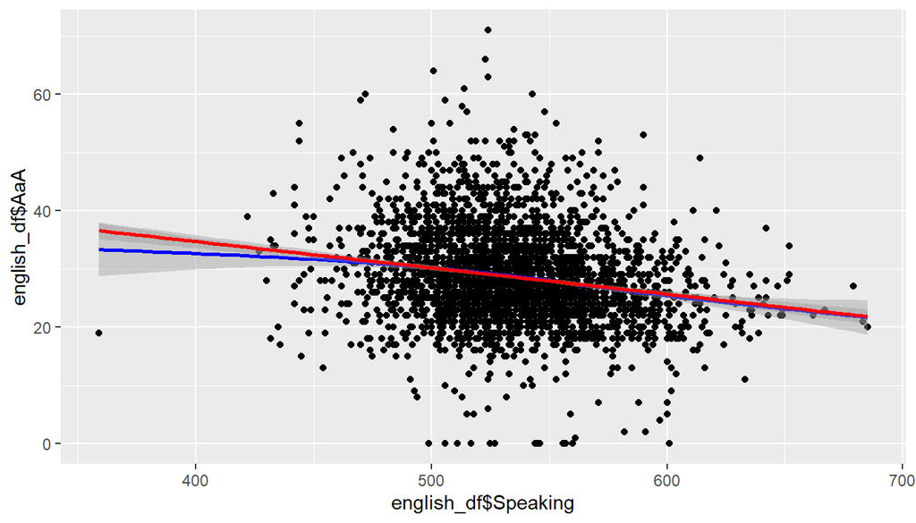

```r
english_df <- df[df$L1 == "English",]
ggplot(english_df, aes(x = english_df$Speaking, y = english_df$AaA)) + geom_point() + geom_smooth(color = "blue") + geom_smooth(method = "lm", color = "red")
```

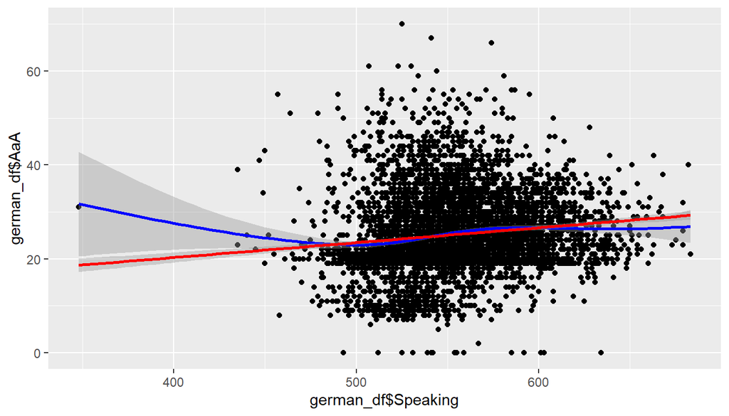

```r
german_df <- df[df$L1 == "German",]
ggplot(german_df, aes(x = german_df$Speaking, y = german_df$AaA)) + geom_point() + geom_smooth(color = "blue") + geom_smooth(method = "lm", color = "red")
```

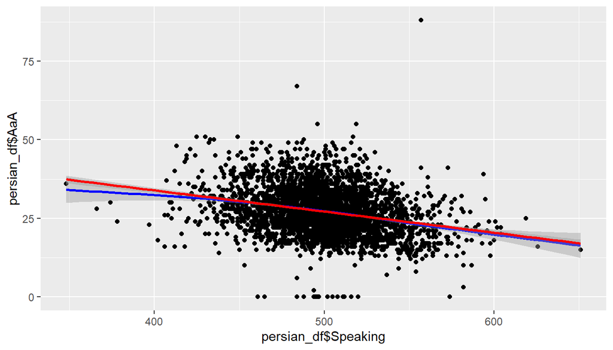

```r
persian_df <- df[df$L1 == "Persian",]
ggplot(persian_df, aes(x = persian_df$Speaking, y = persian_df$AaA)) + geom_point() + geom_smooth(color = "blue") + geom_smooth(method = "lm", color = "red")
```